# #1

# #7 Create box plots for the 2nd , 7th and 8th attribute; one for the whole dataset and one each for the instances of the two classes. Remove 0’s that do not make sense prior to computing the box plots. Interpret and compare the obtained 9 boxplots!

```python
Glucose=df.loc[(df["Glucose"]!=0)]
```

```python
Glucose
```

|  | Pregnancies | Glucose | BloodPressure | SkinThickness | Insulin | BMI | DiabetesPedigreeFunction | Age | Outcome |
| --- | --- | --- | --- | --- | --- | --- | --- | --- | --- |
| 3 | 1 | 89 | 66 | 23 | 94 | 28.1 | 0.167 | 21 | 0 |
| 4 | 0 | 137 | 40 | 35 | 168 | 43.1 | 2.288 | 33 | 1 |
| 6 | 3 | 78 | 50 | 32 | 88 | 31.0 | 0.248 | 26 | 1 |
| 8 | 2 | 197 | 70 | 45 | 543 | 30.5 | 0.158 | 53 | 1 |
| 13 | 1 | 189 | 60 | 23 | 846 | 30.1 | 0.398 | 59 | 1 |
| ... | ... | ... | ... | ... | ... | ... | ... | ... | ... |
| 753 | 0 | 181 | 88 | 44 | 510 | 43.3 | 0.222 | 26 | 1 |
| 755 | 1 | 128 | 88 | 39 | 110 | 36.5 | 1.057 | 37 | 1 |
| 760 | 2 | 88 | 58 | 26 | 16 | 28.4 | 0.766 | 22 | 0 |
| 763 | 10 | 101 | 76 | 48 | 180 | 32.9 | 0.171 | 63 | 0 |
| 765 | 5 | 121 | 72 | 23 | 112 | 26.2 | 0.245 | 30 | 0 |

392 rows × 9 columns

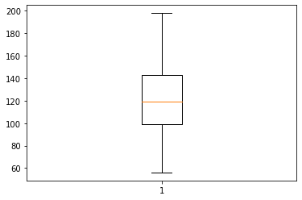

```python
mpl.boxplot(Glucose["Glucose"])
mpl.show()
```

```python
print('Center at 118, there is no outlier, symmetric')
Glucose["Glucose"].describe()
```

```
Center at 118, there is no outlier, symmetric
```

```
count    392.000000
mean     122.627551
std       30.860781
min       56.000000
25%       99.000000
50%      119.000000
75%      143.000000
max      198.000000
Name: Glucose, dtype: float64
```

```python
DiabetesPedigreeFunction=df.loc[(df["DiabetesPedigreeFunction"]!=0)]
```

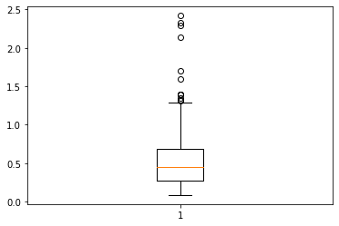

```python
mpl.boxplot(DiabetesPedigreeFunction["DiabetesPedigreeFunction"])
mpl.show()
```

```python
print('Center at 0.4, Skew to right, there is outlier after 1.2')
DiabetesPedigreeFunction["DiabetesPedigreeFunction"].describe()
```

```
Center at 0.4, Skew to right, there is outlier after 1.2
```

```
count    392.000000
mean       0.523046
std        0.345488
min        0.085000
25%        0.269750
50%        0.449500
75%        0.687000
max        2.420000
Name: DiabetesPedigreeFunction, dtype: float64
```

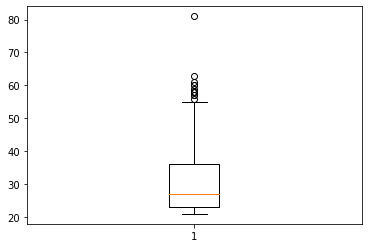

```python
Age=df.loc[(df["Age"]!=0)]
mpl.boxplot(Age["Age"])
mpl.show()
```

```python
print('Center at 25, Skew to right, there is outlier after 55')
Age["DiabetesPedigreeFunction"].describe()
```

```
Center at 25, Skew to right, there is outlier after 55
```

[output not shown]

```python
#Outcome == 1
#-----------------------------------------------

classIns1=diabetes.loc[(diabetes["Outcome"]==1)]
```

```python
classIns1
```

|  | Pregnancies | Glucose | BloodPressure | SkinThickness | Insulin | BMI | DiabetesPedigreeFunction | Age | Outcome |
| --- | --- | --- | --- | --- | --- | --- | --- | --- | --- |
| 4 | 0 | 137 | 40 | 35 | 168 | 43.1 | 2.288 | 33 | 1 |
| 6 | 3 | 78 | 50 | 32 | 88 | 31.0 | 0.248 | 26 | 1 |
| 8 | 2 | 197 | 70 | 45 | 543 | 30.5 | 0.158 | 53 | 1 |
| 13 | 1 | 189 | 60 | 23 | 846 | 30.1 | 0.398 | 59 | 1 |
| 14 | 5 | 166 | 72 | 19 | 175 | 25.8 | 0.587 | 51 | 1 |
| ... | ... | ... | ... | ... | ... | ... | ... | ... | ... |
| 732 | 2 | 174 | 88 | 37 | 120 | 44.5 | 0.646 | 24 | 1 |
| 740 | 11 | 120 | 80 | 37 | 150 | 42.3 | 0.785 | 48 | 1 |
| 748 | 3 | 187 | 70 | 22 | 200 | 36.4 | 0.408 | 36 | 1 |
| 753 | 0 | 181 | 88 | 44 | 510 | 43.3 | 0.222 | 26 | 1 |
| 755 | 1 | 128 | 88 | 39 | 110 | 36.5 | 1.057 | 37 | 1 |

130 rows × 9 columns

```python
Glucose=classIns1.loc[(classIns1.Glucose!=0)]
(Glucose.Glucose==0).sum()
```

```
0
```

[output not shown]

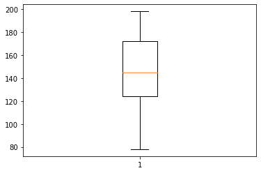

```python
mpl.boxplot(Glucose["Glucose"])
```

```python
print('Skew to left, there is no outlier')
```

```
Skew to left, there is no outlier
```

[output not shown]

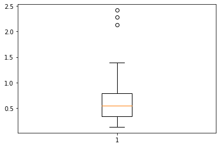

```python
mpl.boxplot(classIns1["DiabetesPedigreeFunction"])
```

```python
(classIns1["DiabetesPedigreeFunction"]==0).sum()
```

```
0
```

```python
print('Skew to right, there is outlier after 2.2')
```

```
Skew to right, there is outlier after 2.2
```

[output not shown]

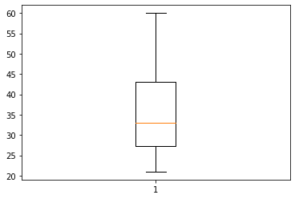

```python
mpl.boxplot(classIns1["Age"])
```

```python
(classIns1["Age"]==0).sum()
#classIns1["Age"].describe()
```

```
0
```

```python
print('Skew to right, there is no outlier')
```

```
Skew to right, there is no outlier
```

```python
#Outcome=0
classIns0=diabetes.loc[(diabetes["Outcome"]==0)]
```

```python
classIns0
```

|  | Pregnancies | Glucose | BloodPressure | SkinThickness | Insulin | BMI | DiabetesPedigreeFunction | Age | Outcome |
| --- | --- | --- | --- | --- | --- | --- | --- | --- | --- |
| 3 | 1 | 89 | 66 | 23 | 94 | 28.1 | 0.167 | 21 | 0 |
| 18 | 1 | 103 | 30 | 38 | 83 | 43.3 | 0.183 | 33 | 0 |
| 20 | 3 | 126 | 88 | 41 | 235 | 39.3 | 0.704 | 27 | 0 |
| 27 | 1 | 97 | 66 | 15 | 140 | 23.2 | 0.487 | 22 | 0 |
| 28 | 13 | 145 | 82 | 19 | 110 | 22.2 | 0.245 | 57 | 0 |
| ... | ... | ... | ... | ... | ... | ... | ... | ... | ... |
| 747 | 1 | 81 | 74 | 41 | 57 | 46.3 | 1.096 | 32 | 0 |
| 751 | 1 | 121 | 78 | 39 | 74 | 39.0 | 0.261 | 28 | 0 |
| 760 | 2 | 88 | 58 | 26 | 16 | 28.4 | 0.766 | 22 | 0 |
| 763 | 10 | 101 | 76 | 48 | 180 | 32.9 | 0.171 | 63 | 0 |
| 765 | 5 | 121 | 72 | 23 | 112 | 26.2 | 0.245 | 30 | 0 |

262 rows × 9 columns

```python
Glucose=classIns0.loc[(classIns0.Glucose!=0)]
(Glucose["Glucose"]==0).sum()
```

```
0
```

[output not shown]

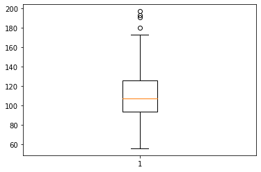

```python
mpl.boxplot(Glucose["Glucose"])
```

```python
Glucose["Glucose"].describe()
```

```
count    262.000000
mean     111.431298
std       24.642133
min       56.000000
25%       94.000000
50%      107.500000
75%      126.000000
max      197.000000
Name: Glucose, dtype: float64
```

```python
print('Center at 110, there is outlier after 180')
```

```
Center at 110, there is outlier after 180
```

```python
(classIns0["DiabetesPedigreeFunction"]==0).sum()
```

```
0
```

[output not shown]

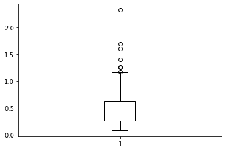

```python
mpl.boxplot(classIns0["DiabetesPedigreeFunction"])
```

```python
print('Skew to right, there is outlier after 1.1')
```

```
Skew to right, there is outlier after 1.1
```

```python
(classIns0["Age"]==0).sum()
```

```
0
```

[output not shown]

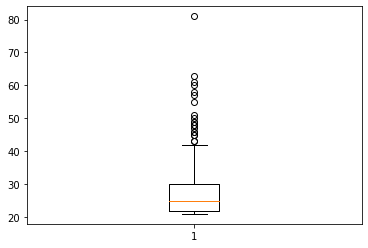

```python
mpl.boxplot(classIns0["Age"])
```

```python
print('Skew to right, there is outlier after 41')
```

```
Skew to right, there is outlier after 41
```

```python
classIns0["Age"].describe()
```

```
count    262.000000
mean      28.347328
std        8.989008
min       21.000000
25%       22.000000
50%       25.000000
75%       30.000000
max       81.000000
Name: Age, dtype: float64
```

```python
#compare
#----------------------------------------
print("For Glucose plots, people with lesser Glucose seem to less likely have diabetes. The diabetesPedigreeFunction does not indicate significant difference between two classes. The age displays a very obvious prediction that people with older age tend to have diabetes more than people wiith younger age")
```

```
For Glucose plots, people with lesser Glucose seem to less likely have diabetes. The diabetesPedigreeFunction does not indicate significant difference between two classes. The age displays a very obvious prediction that people with older age tend to have diabetes more than people wiith younger age
```

# #8 Create supervised scatter plots for all pairs of attributes 2-6—these are 10 plots. Next create two 3D-scatterplots: one for attributes 2, 3, 6 and one for attributes 2, 4, 6. Interpret the obtained scatter plots; in particular address what can be said about the difficulty in predicting diabetes. Assess the usefulness of the 3D scatterplot compared to the 2D plots!

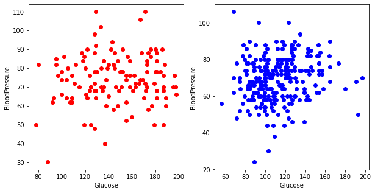

```python
mpl.figure(figsize=(10,5))
mpl.subplot(1,2,1)
mpl.scatter(class1.Glucose,class1.BloodPressure,color="red")
mpl.xlabel("Glucose")
mpl.ylabel("BloodPressure")
mpl.subplot(1,2,2)
mpl.scatter(class2.Glucose,class2.BloodPressure,color="blue")
mpl.xlabel("Glucose")
mpl.ylabel("BloodPressure")

#class2=Outcome is 0
#class1=Outcome is 1
```

Class 1: Scatter plot does not have center. The data spreads in different direction. There is no trend. Outliers locate at BloodPressure > 100 or BloodPressure < 40 Class 0: Scatter plot has cluster at (110,70) in range Glucose(60,160) and BloodPressure(40,90). Outliers locate in out of the center range. Class 0 gives the more accurate data to predict the outcome due to the dense of the cluster at center point. Class 1 is harder to predict

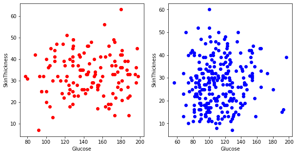

```python
mpl.figure(figsize=(10,5))
mpl.subplot(1,2,1)
mpl.scatter(class1.Glucose,class1.SkinThickness,color="red")
mpl.xlabel("Glucose")
mpl.ylabel("SkinThickness")
mpl.subplot(1,2,2)
mpl.scatter(class2.Glucose,class2.SkinThickness,color="blue")
mpl.xlabel("Glucose")
mpl.ylabel("SkinThickness")


#class2=Outcome is 0
#class1=Outcome is 1
```

Class 1: Scatter plot does not have center. The data vary in different direction and spread more horizontally. There is no trend. Class 0: Scatter plot has cluster in range Glucose(60,160) and SkinThickness(10,50). Outliers locate in out of the these range. There is no trend Both class 1 and class 0 are not easy for interpreting using.

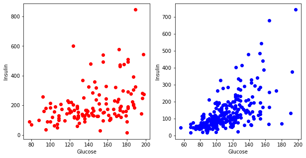

```python
mpl.figure(figsize=(10,5))
mpl.subplot(1,2,1)
mpl.scatter(class1.Glucose,class1.Insulin,color="red")
mpl.xlabel("Glucose")
mpl.ylabel("Insulin")

mpl.subplot(1,2,2)
mpl.scatter(class2.Glucose,class2.Insulin,color="blue")
mpl.xlabel("Glucose")
mpl.ylabel("Insulin")


#class2=Outcome is 0
#class1=Outcome is 1
```

Class 1: Scatter plot does not have center. The data vary in different direction and spread more horizontally. There is a weak positive linear relationship. Class 0: Scatter plot has cluster in range Glucose(60,160) and Insulin(0,500). Outliers locate in out of the these range. There is a positive relationship which stronger comparing to class 1 Both class 1 and class 0 are showing a positive relationship to Insulin

```
1								0
```

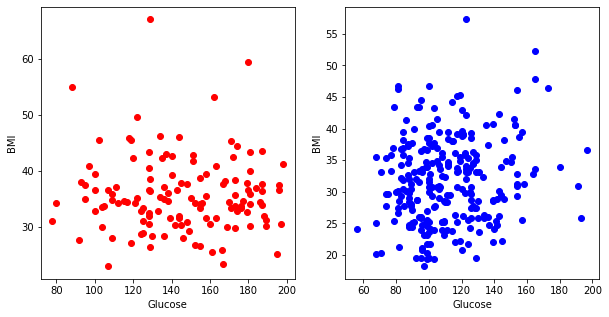

```python
mpl.figure(figsize=(10,5))
print("1", end='\t\t\t\t\t\t\t\t')
print("0")
mpl.subplot(1,2,1)
mpl.scatter(class1.Glucose,class1.BMI,color="red")
mpl.xlabel("Glucose")
mpl.ylabel("BMI")

mpl.subplot(1,2,2)
mpl.scatter(class2.Glucose,class2.BMI,color="blue")
mpl.xlabel("Glucose")
mpl.ylabel("BMI")


#class2=Outcome is 0
#class1=Outcome is 1
```

Class 1: Scatter plot does not have center. The data vary in different direction and spread more horizontally. There is no trend. Class 0: Scatter plot does not have center. The density is higher than class 1. The data vary in different direction and spread more horizontally. There is no trend. Both class 1 and class 0 are hard for interpreting

```
    1								0
```

[figure not shown]

```python
#BloodPressure
mpl.figure(figsize=(10,5))
print("    1", end='\t\t\t\t\t\t\t\t')
print("0")
mpl.subplot(1,2,1)
mpl.scatter(class1.BloodPressure,class1.SkinThickness,color="red")
mpl.xlabel("SkinThickness")
mpl.ylabel("BloodPressure")

mpl.subplot(1,2,2)
mpl.scatter(class2.BloodPressure,class2.SkinThickness,color="blue")
mpl.xlabel("SkinThickness")
mpl.ylabel("BloodPressure")


#class2=Outcome is 0
#class1=Outcome is 1
```

Class 1: Scatter plot does not have center. The data vary in different direction and spread more vertically. There is no trend. Class 0: Scatter plot does not have center. The density is higher than class 1. The data vary in different direction and spread more vertically. There is no trend. Both class 1 and class 0 are hard for interpreting

```
    1								0
```

[figure not shown]

```python
#BloodPressure
mpl.figure(figsize=(10,5))
print("    1", end='\t\t\t\t\t\t\t\t')
print("0")
mpl.subplot(1,2,1)
mpl.scatter(class1.BloodPressure,class1.Insulin,color="red")
mpl.xlabel("Insulin")
mpl.ylabel("BloodPressure")

mpl.subplot(1,2,2)
mpl.scatter(class2.BloodPressure,class2.Insulin,color="blue")
mpl.xlabel("Insulin")
mpl.ylabel("BloodPressure")


#class2=Outcome is 0
#class1=Outcome is 1
```

Class 1: Scatter plot have center in range BloodPressure(50,100) and Insulin(0,200). There is no trend, and outliers locate at Insulin = 600 and above Class 0: Scatter plot have center in range BloodPressure(40,100) and Insulin(0,200). The desity is a bit higher than class 1. There is no trend, and outliers locate vertically at Insulin = 500 and above

Both class 1 and class 0 are hard for interpreting

```
    1								0
```

[figure not shown]

```python
#BloodPressure
mpl.figure(figsize=(10,5))
print("    1", end='\t\t\t\t\t\t\t\t')
print("0")
mpl.subplot(1,2,1)
mpl.scatter(class1.BloodPressure,class1.BMI,color="red")
mpl.xlabel("BMI")
mpl.ylabel("BloodPressure")

mpl.subplot(1,2,2)
mpl.scatter(class2.BloodPressure,class2.BMI,color="blue")
mpl.xlabel("BMI")
mpl.ylabel("BloodPressure")


#class2=Outcome is 0
#class1=Outcome is 1
```

Class 1: Scatter plot does not have center. The data vary in different direction and spread more vertically. There is no trend. Class 0: Scatter plot does not have center. The density is higher than class 1. The data vary in different direction and spread more vertically. There is no trend. Both class 1 and class 0 are hard for interpreting

```
    1								0
```

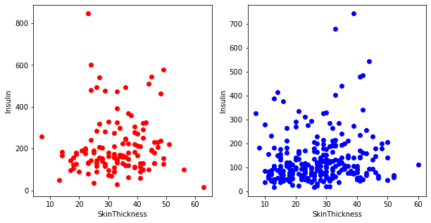

```python
#SkinThickness
mpl.figure(figsize=(10,5))
print("    1", end='\t\t\t\t\t\t\t\t')
print("0")
mpl.subplot(1,2,1)
mpl.scatter(class1.SkinThickness,class1.Insulin,color="red")
mpl.xlabel("SkinThickness")
mpl.ylabel("Insulin")

mpl.subplot(1,2,2)
mpl.scatter(class2.SkinThickness,class2.Insulin,color="blue")
mpl.xlabel("SkinThickness")
mpl.ylabel("Insulin")


#class2=Outcome is 0
#class1=Outcome is 1
```

```
    1								0
```

[figure not shown]

```python
#SkinThickness
mpl.figure(figsize=(10,5))
print("    1", end='\t\t\t\t\t\t\t\t')
print("0")
mpl.subplot(1,2,1)
mpl.scatter(class1.BMI,class1.SkinThickness,color="red")
mpl.xlabel("SkinThickness")
mpl.ylabel("BMI")

mpl.subplot(1,2,2)
mpl.scatter(class2.BMI,class2.SkinThickness,color="blue")
mpl.xlabel("SkinThickness")
mpl.ylabel("BMI")


#class2=Outcome is 0
#class1=Outcome is 1
```

```
    1								0
```

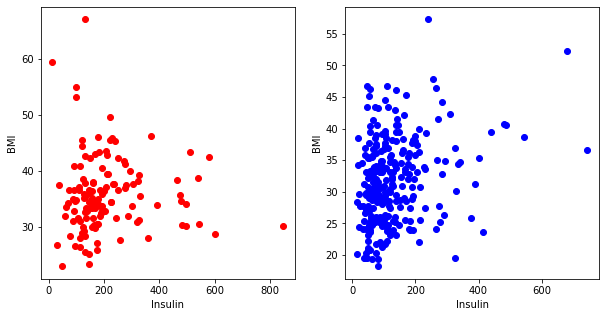

```python
#Insulin
mpl.figure(figsize=(10,5))
print("    1", end='\t\t\t\t\t\t\t\t')
print("0")
mpl.subplot(1,2,1)
mpl.scatter(class1.Insulin,class1.BMI,color="red")
mpl.xlabel("Insulin")
mpl.ylabel("BMI")

mpl.subplot(1,2,2)
mpl.scatter(class2.Insulin,class2.BMI,color="blue")
mpl.xlabel("Insulin")
mpl.ylabel("BMI")


#class2=Outcome is 0
#class1=Outcome is 1
```

Class 1: Scatter plot has cluster at range Insulin(0,600) and BMI(0, 50). There is no trending. Outliers at (200,70) and (820,30) Class 0: Scatter plot has cluster at range Insulin(0, 400) and BMI(0, 50). There is no trending. Outliers at (220,60), (620,52), (700,37) Both class 1 and class 0 are hard to predict the outcome

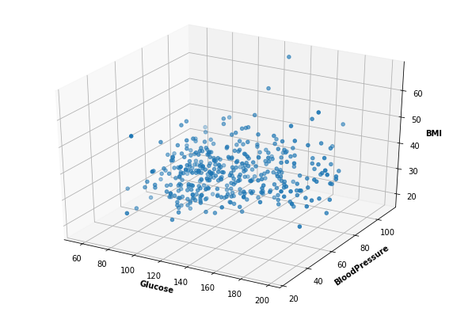

```python
#3-d Scatterplot
fig = mpl.figure(figsize = (10, 7))
ax = mpl.axes(projection ="3d")
#ax.scatter3D(diabetes.Glucose, diabetes.BloodPressure, diabetes.BMI);
ax.scatter3D(diabetes.iloc[:,1:2], diabetes.iloc[:,2:3], diabetes.iloc[:,5:6]);


ax.set_xlabel('Glucose', fontweight ='bold')
ax.set_ylabel('BloodPressure', fontweight ='bold')
ax.set_zlabel('BMI', fontweight ='bold')
```

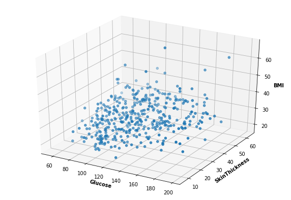

```python
#3-d Scatterplot
fig = mpl.figure(figsize = (10, 7))
ax = mpl.axes(projection ="3d")
#ax.scatter3D(diabetes_full.Glucose, diabetes_full.BloodPressure, diabetes_full.BMI);
ax.scatter3D(diabetes.iloc[:,1:2], diabetes.iloc[:,3:4], diabetes.iloc[:,5:6]);


ax.set_xlabel('Glucose', fontweight ='bold')
ax.set_ylabel('SkinThickness', fontweight ='bold')
ax.set_zlabel('BMI', fontweight ='bold')
```

```python
print("Among 2d scatter plots, class 0 plots give more accurate data with trending and high density than class 1.2d scatter plots are better to interpret data relationship if there is no preceding information prior to the computation. However, if there is relationships provided, the 3d scatter plots will be better to interpret the tripple relationships. In this dataset, there is no relationships provided and all relationships have to be interpretted through computation, the 2d scatter plots are more precise to be deployed.")
```

[output not shown]

# #9 Fit a linear model that predicts the class attribute using the 8 z-scored, continuous attributes of the cleaned dataset as independent variables . Report the R2 of the linear model and the coefficients of each attribute in the obtained regression function. Next, drop the two attributes, whose coefficients are the closest to 0, and obtain a linear model using the six remaining attributes as independent variable. Do the coefficients tell you anything about the importance of the attribute in predicting diabetes? What about negative and positive coefficients? Also compare the two regression functions!

```python
#for col in diabete_clean:
    #col_zscore = col + '_zscore'
    #df[col_zscore] = (df[col] - df[col].mean())/df[col].std(ddof=0)
```

```python
#df
```

```python
#columns=["6","148","72","35","156","33.6","0.627","50"]
diabete_clean=pd.read_csv("/home/assmin/Desktop/Data Science/homework/diabetes_cleaned.csv",names=["Pregnancies","Glucose","BloodPressure","SkinThickness","Insulin","BMI","DiabetesPedigreeFunction","Age","Outcome"])
```

```python
df=pd.DataFrame(diabete_clean)
df
```

|  | Pregnancies | Glucose | BloodPressure | SkinThickness | Insulin | BMI | DiabetesPedigreeFunction | Age | Outcome |
| --- | --- | --- | --- | --- | --- | --- | --- | --- | --- |
| 0 | 6 | 148 | 72 | 35 | 156 | 33.6 | 0.627 | 50 | 1 |
| 1 | 1 | 85 | 66 | 29 | 156 | 26.6 | 0.351 | 31 | 0 |
| 2 | 8 | 183 | 64 | 29 | 156 | 23.3 | 0.672 | 32 | 1 |
| 3 | 1 | 89 | 66 | 23 | 94 | 28.1 | 0.167 | 21 | 0 |
| 4 | 0 | 137 | 40 | 35 | 168 | 43.1 | 2.288 | 33 | 1 |
| ... | ... | ... | ... | ... | ... | ... | ... | ... | ... |
| 763 | 10 | 101 | 76 | 48 | 180 | 32.9 | 0.171 | 63 | 0 |
| 764 | 2 | 122 | 70 | 27 | 156 | 36.8 | 0.340 | 27 | 0 |
| 765 | 5 | 121 | 72 | 23 | 112 | 26.2 | 0.245 | 30 | 0 |
| 766 | 1 | 126 | 60 | 29 | 156 | 30.1 | 0.349 | 47 | 1 |
| 767 | 1 | 93 | 70 | 31 | 156 | 30.4 | 0.315 | 23 | 0 |

768 rows × 9 columns

```python
z_score=df.iloc[:,0:8].apply(zscore)
z_score
```

|  | Pregnancies | Glucose | BloodPressure | SkinThickness | Insulin | BMI | DiabetesPedigreeFunction | Age |
| --- | --- | --- | --- | --- | --- | --- | --- | --- |
| 0 | 0.639947 | 0.865041 | -0.031990 | 0.670643 | 0.002728 | 0.167240 | 0.468492 | 1.425995 |
| 1 | -0.844885 | -1.206228 | -0.528319 | -0.012301 | 0.002728 | -0.851551 | -0.365061 | -0.190672 |
| 2 | 1.233880 | 2.015746 | -0.693761 | -0.012301 | 0.002728 | -1.331838 | 0.604397 | -0.105584 |
| 3 | -0.844885 | -1.074719 | -0.528319 | -0.695245 | -0.726976 | -0.633239 | -0.920763 | -1.041549 |
| 4 | -1.141852 | 0.503391 | -2.679076 | 0.670643 | 0.143961 | 1.549885 | 5.484909 | -0.020496 |
| ... | ... | ... | ... | ... | ... | ... | ... | ... |
| 763 | 1.827813 | -0.680192 | 0.298896 | 2.150354 | 0.285194 | 0.065361 | -0.908682 | 2.532136 |
| 764 | -0.547919 | 0.010231 | -0.197433 | -0.239949 | 0.002728 | 0.632973 | -0.398282 | -0.531023 |
| 765 | 0.342981 | -0.022646 | -0.031990 | -0.695245 | -0.515126 | -0.909768 | -0.685193 | -0.275760 |
| 766 | -0.844885 | 0.141740 | -1.024647 | -0.012301 | 0.002728 | -0.342155 | -0.371101 | 1.170732 |
| 767 | -0.844885 | -0.943210 | -0.197433 | 0.215347 | 0.002728 | -0.298493 | -0.473785 | -0.871374 |

768 rows × 8 columns

```python
result = sm.ols(formula="Outcome ~ z_score", data=df).fit()

print(result.summary())
```

```
                            OLS Regression Results
==============================================================================
Dep. Variable:                Outcome   R-squared:                       0.321
Model:                            OLS   Adj. R-squared:                  0.314
Method:                 Least Squares   F-statistic:                     44.85
Date:                Sun, 20 Sep 2020   Prob (F-statistic):           4.86e-59
Time:                        19:56:19   Log-Likelihood:                -372.00
No. Observations:                 768   AIC:                             762.0
Df Residuals:                     759   BIC:                             803.8
Df Model:                           8
Covariance Type:            nonrobust
==============================================================================
                 coef    std err          t      P>|t|      [0.025      0.975]
------------------------------------------------------------------------------
Intercept      0.3490      0.014     24.478      0.000       0.321       0.377
z_score[0]     0.0697      0.017      4.089      0.000       0.036       0.103
z_score[1]     0.1966      0.017     11.858      0.000       0.164       0.229
z_score[2]    -0.0140      0.016     -0.882      0.378      -0.045       0.017
z_score[3]     0.0014      0.017      0.083      0.934      -0.032       0.035
z_score[4]    -0.0076      0.016     -0.478      0.633      -0.039       0.023
z_score[5]     0.0990      0.018      5.545      0.000       0.064       0.134
z_score[6]     0.0428      0.015      2.935      0.003       0.014       0.071
z_score[7]     0.0247      0.018      1.361      0.174      -0.011       0.060
==============================================================================
Omnibus:                       32.824   Durbin-Watson:                   1.962
Prob(Omnibus):                  0.000   Jarque-Bera (JB):               23.454
Skew:                           0.319   Prob(JB):                     8.07e-06
Kurtosis:                       2.430   Cond. No.                         2.45
==============================================================================

Warnings:
[1] Standard Errors assume that the covariance matrix of the errors is correctly specified.
```

```python
print(result.rsquared)
#print(result.summary())
```

```
0.32100318397582794
```

```python
print(result.params)
```

```
Intercept     0.348958
z_score[0]    0.069717
z_score[1]    0.196633
z_score[2]   -0.014003
z_score[3]    0.001426
z_score[4]   -0.007557
z_score[5]    0.099028
z_score[6]    0.042785
z_score[7]    0.024679
dtype: float64
```

```python
clean=df.iloc[:,0:8]

for col in clean:
    col_zscore = col + '-zscore'
    clean[col_zscore] = (clean[col] - clean[col].mean())/clean[col].std(ddof=0)
```

```python
clean
```

|  | Pregnancies | Glucose | BloodPressure | SkinThickness | Insulin | BMI | DiabetesPedigreeFunction | Age | Pregnancies-zscore | Glucose-zscore | BloodPressure-zscore | SkinThickness-zscore | Insulin-zscore | BMI-zscore | DiabetesPedigreeFunction-zscore | Age-zscore |
| --- | --- | --- | --- | --- | --- | --- | --- | --- | --- | --- | --- | --- | --- | --- | --- | --- |
| 0 | 6 | 148 | 72 | 35 | 156 | 33.6 | 0.627 | 50 | 0.639947 | 0.865041 | -0.031990 | 0.670643 | 0.002728 | 0.167240 | 0.468492 | 1.425995 |
| 1 | 1 | 85 | 66 | 29 | 156 | 26.6 | 0.351 | 31 | -0.844885 | -1.206228 | -0.528319 | -0.012301 | 0.002728 | -0.851551 | -0.365061 | -0.190672 |
| 2 | 8 | 183 | 64 | 29 | 156 | 23.3 | 0.672 | 32 | 1.233880 | 2.015746 | -0.693761 | -0.012301 | 0.002728 | -1.331838 | 0.604397 | -0.105584 |
| 3 | 1 | 89 | 66 | 23 | 94 | 28.1 | 0.167 | 21 | -0.844885 | -1.074719 | -0.528319 | -0.695245 | -0.726976 | -0.633239 | -0.920763 | -1.041549 |
| 4 | 0 | 137 | 40 | 35 | 168 | 43.1 | 2.288 | 33 | -1.141852 | 0.503391 | -2.679076 | 0.670643 | 0.143961 | 1.549885 | 5.484909 | -0.020496 |
| ... | ... | ... | ... | ... | ... | ... | ... | ... | ... | ... | ... | ... | ... | ... | ... | ... |
| 763 | 10 | 101 | 76 | 48 | 180 | 32.9 | 0.171 | 63 | 1.827813 | -0.680192 | 0.298896 | 2.150354 | 0.285194 | 0.065361 | -0.908682 | 2.532136 |
| 764 | 2 | 122 | 70 | 27 | 156 | 36.8 | 0.340 | 27 | -0.547919 | 0.010231 | -0.197433 | -0.239949 | 0.002728 | 0.632973 | -0.398282 | -0.531023 |
| 765 | 5 | 121 | 72 | 23 | 112 | 26.2 | 0.245 | 30 | 0.342981 | -0.022646 | -0.031990 | -0.695245 | -0.515126 | -0.909768 | -0.685193 | -0.275760 |
| 766 | 1 | 126 | 60 | 29 | 156 | 30.1 | 0.349 | 47 | -0.844885 | 0.141740 | -1.024647 | -0.012301 | 0.002728 | -0.342155 | -0.371101 | 1.170732 |
| 767 | 1 | 93 | 70 | 31 | 156 | 30.4 | 0.315 | 23 | -0.844885 | -0.943210 | -0.197433 | 0.215347 | 0.002728 | -0.298493 | -0.473785 | -0.871374 |

768 rows × 16 columns

```python
result = sm.ols(formula="Outcome ~Pregnancies-zscore+Glucose-zscore+BloodPressure-zscore+BMI-zscore+DiabetesPedigreeFunction-zscore+Age-zscore ", data=df).fit()

print(result.summary())
```

```
                            OLS Regression Results
==============================================================================
Dep. Variable:                Outcome   R-squared:                       0.321
Model:                            OLS   Adj. R-squared:                  0.315
Method:                 Least Squares   F-statistic:                     59.90
Date:                Sun, 20 Sep 2020   Prob (F-statistic):           9.05e-61
Time:                        19:56:19   Log-Likelihood:                -372.12
No. Observations:                 768   AIC:                             758.2
Df Residuals:                     761   BIC:                             790.7
Df Model:                           6
Covariance Type:            nonrobust
============================================================================================
                               coef    std err          t      P>|t|      [0.025      0.975]
--------------------------------------------------------------------------------------------
Intercept                   -1.0222      0.104     -9.854      0.000      -1.226      -0.819
Pregnancies                  0.0207      0.005      4.102      0.000       0.011       0.031
Glucose                      0.0064      0.001     12.630      0.000       0.005       0.007
BloodPressure               -0.0011      0.001     -0.860      0.390      -0.004       0.001
BMI                          0.0144      0.002      6.462      0.000       0.010       0.019
DiabetesPedigreeFunction     0.1286      0.044      2.926      0.004       0.042       0.215
Age                          0.0021      0.002      1.354      0.176      -0.001       0.005
==============================================================================
Omnibus:                       31.401   Durbin-Watson:                   1.963
Prob(Omnibus):                  0.000   Jarque-Bera (JB):               22.706
Skew:                           0.315   Prob(JB):                     1.17e-05
Kurtosis:                       2.441   Cond. No.                     1.11e+03
==============================================================================

Warnings:
[1] Standard Errors assume that the covariance matrix of the errors is correctly specified.
[2] The condition number is large, 1.11e+03. This might indicate that there are
strong multicollinearity or other numerical problems.
```